# Hypothesis Test for a Population Mean

Yuanting Lu

11/19/2025

- $H_0: \mu = \mu_0$
- $H_1: \mu\ne \mu_0, \mu>\mu_0,$ or $\mu < \mu_0$
- Test statistic: $t$
- P-value.

### With Unknown $\sigma$

**Ross 9.6** Historical data indicate that the mean acidity (pH) level of rain in a certain industrial region in West Virginia is 5.2. To see whether there has been any recent change in this value, the acidity levels of 12 rainstorms over the past year have been measured, with the following results:
$$6.1,
5.4, 4.8, 5.8, 6.6, 5.3, 6.1, 4.4, 3.9, 6.8, 6.5, 6.3$$
Are these data strong enough, at the 5 percent level of significance, for us to conclude that the acidity of the rain has changed from its historical value?

**Ross 9.7** The manufacturer of a new fiberglass tire claims that the average life of a set of its tires is at least 50,000 miles. To verify this claim, a sample of 8 sets of tires was chosen, and the tires subsequently were tested by a consumer agency. If the resulting values of the sample mean and sample variance were, respectively, 47.2 and 3.1 (in 1000 miles), test the manufacturer’s claim.

### Assessing Normalty for Small Samples

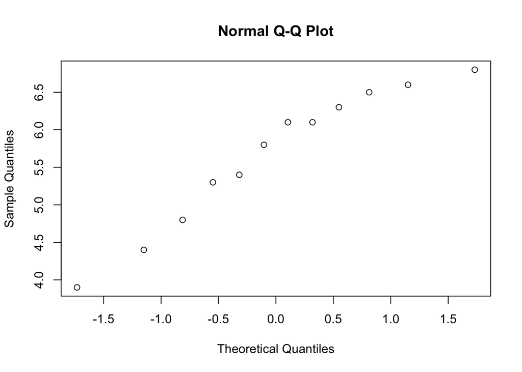

```r
x <- c(6.1, 5.4, 4.8, 5.8, 6.6, 5.3, 6.1, 4.4, 3.9, 6.8, 6.5, 6.3)
x_sorted <- sort(x)
n <- 12
z <- qnorm(ppoints(n))
qqnorm(x)
```

```r
cor(z, x_sorted)
```

```
## [1] 0.9705555
```

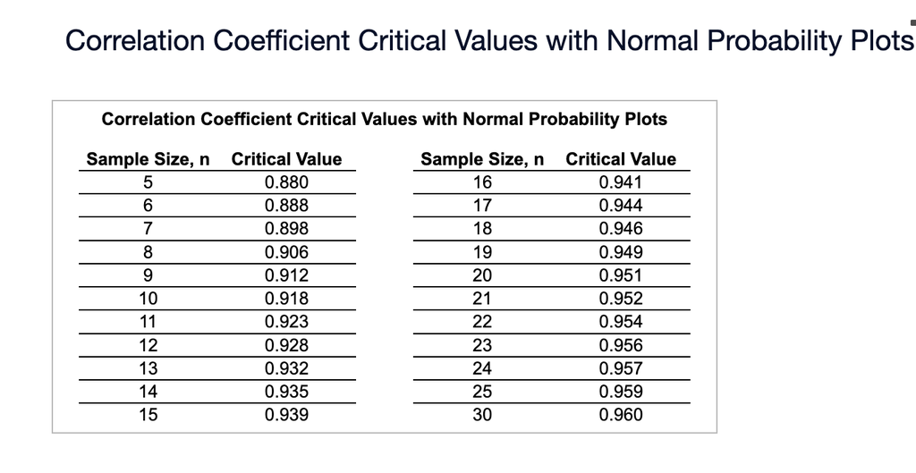